# PHStatsII-HW3b

Marty Ross

2022-10-02

```r
knitr::opts_chunk$set(echo = TRUE)
library(tidyverse)
setwd("~/SpatialAnalysis/01-2022_PHStatsII/Assignments/A3/A3ptB")
casData <- read.csv("casData.csv")
# head(casData)
# Part A:  GPA by drinking
# class(casData$DRINK)
# table(casData$DRINK)
# make DRINK a factor with labels (helpful for visual displays, cuts down on code
# needed to label groups)
casData <- casData %>%
  mutate(DRINK = factor(DRINK, levels = c(0, 1), labels = c("Non-drinker",
                                                            "Drinker")))
```

# Part A: What is the unadjusted relationship between GPA and consumption of alcohol?

Q1: Simple Boxplot of GPA by drinking status

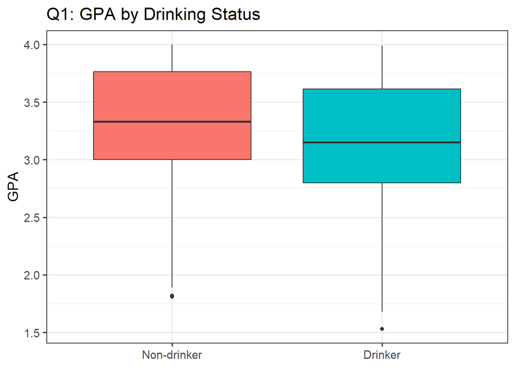

```r
ggplot(casData, aes(x = DRINK, y = GPA, fill = DRINK)) +
  geom_boxplot() +
  theme_bw(base_size = 14) +
  labs(title = 'Q1: GPA by Drinking Status') +
  theme(axis.title.x = element_blank(),
        legend.position = 'none')
```

Q2-3. Regress by Drinking Status

```r
model1 <- lm(GPA ~ DRINK, data = casData)
# summary(model1)
co1 <- model1$coefficients
cat('Q2. Estimated mean difference in GPA for students who drink versus those',
          'who do not: \n', round(co1[2], 2))
```

```
## Q2. Estimated mean difference in GPA for students who drink versus those who do not:
##  -0.18
```

```r
conf1 <- confint(model1)
cat('Q3. 95% Confidence interval difference in GPA for students who drink versus those',
          'who do not: \n', round(conf1[2,], 2))
```

```
## Q3. 95% Confidence interval difference in GPA for students who drink versus those who do not:
##  -0.28 -0.08
```

# Part B: What is the relationship between GPA and consumption of alcohol, when adjusted for a student’s age?

Q4: A scatterplot showing the relationship between GPA and a student’s age

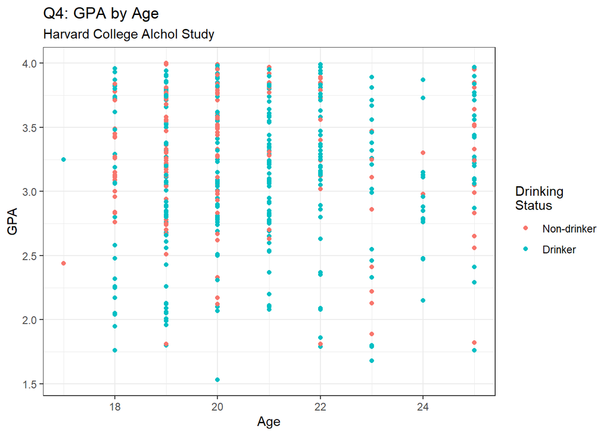

```r
ggplot(casData, aes(x = age, y = GPA, color = DRINK)) +
  geom_point() +
  theme_bw() +
  labs(x = 'Age', color = 'Drinking\nStatus',
       title = 'Q4: GPA by Age',
       subtitle = 'Harvard College Alchol Study')
```

Q5. Side-by-side boxplots showing the difference in age between students who drink and students who do not drink. *Note: I wasn’t certain I was fulfilling this correctly based on the starter code and how the question was phrased, so I’m giving a couple options.*

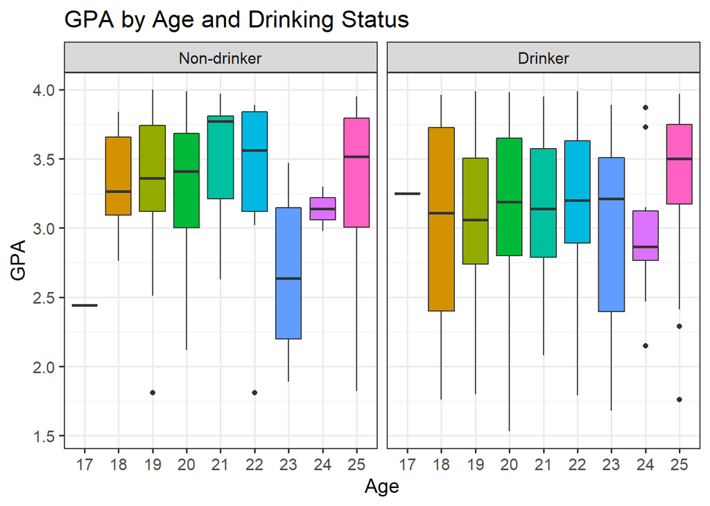

```r
casData <- casData %>% mutate(agef = factor(age))

ggplot(casData, aes(x = agef, y = GPA, fill = agef)) +
  geom_boxplot() +
  facet_wrap(facets = casData$DRINK) +
  theme_bw(base_size = 14) +
  theme(legend.position = 'none') +
  labs(x = 'Age', title = 'GPA by Age and Drinking Status')
```

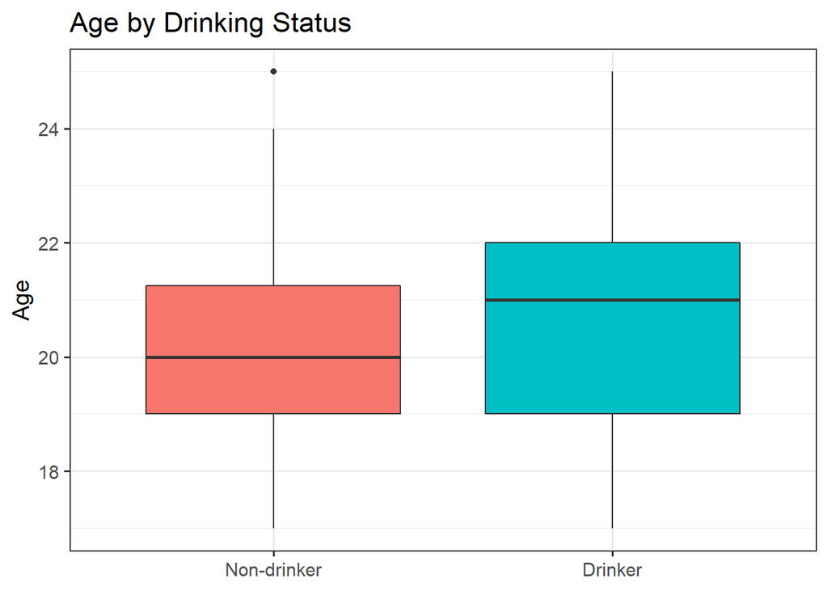

```r
ggplot(casData, aes(x = DRINK, y = age, fill = DRINK)) +
  geom_boxplot() +
  theme_bw(base_size = 14) +
  theme(legend.position = 'none',
        axis.title.x = element_blank()) +
  labs(y = 'Age',
       title = 'Age by Drinking Status')
```

Q6-9 Multiple Regression on GPA, Drinking + age

```r
model2 <- lm(GPA ~ DRINK + age, data = casData)
# summary(model2)
co2 <- coef(model2)
# The estimated mean GPA for 20-year-old students who drink
cat('Q6. The estimated mean GPA for 20-year-old students who drink:\n  ',
    round(co2[1] + co2[2]*1 + co2[3]*20,2))
```

```
## Q6. The estimated mean GPA for 20-year-old students who drink:
##    3.11
```

```r
cat('Q7. The estimated mean GPA for 20-year-old students who do not drink:\n  ',
    round(co2[1] + co2[2]*0 + co2[3]*20, 2))
```

```
## Q7. The estimated mean GPA for 20-year-old students who do not drink:
##    3.3
```

```r
cat('Q8. The estimated mean difference in GPA for students who drink, compared to students of the same age who do not:\n  ', round(co2[2], 2))
```

```
## Q8. The estimated mean difference in GPA for students who drink, compared to students of the same age who do not:
##    -0.19
```

```r
conf2 <- confint(model2)
cat(paste0('Q9. A 95% confidence interval for this estimated difference:\n  (',
    round(conf2[2,1],2), ',', round(conf2[2,2],2),')'))
```

```
## Q9. A 95% confidence interval for this estimated difference:
##   (-0.29,-0.08)
```

## Part C: What is the relationship between GPA and consumption of alcohol, when adjusted for a student’s year in school?

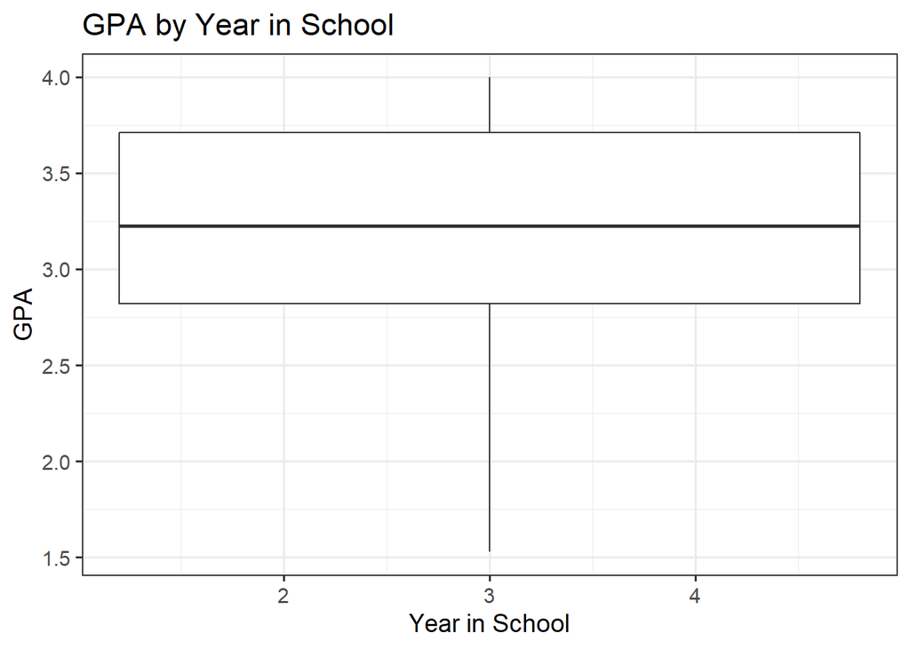

```r
#  created factor version of year in school
casData <- casData %>%
  mutate(schoolyrf = factor(schoolyr,
                           labels = c("Freshman", "Sophomore", "Junior", "Senior",
                                      "5th year plus")))
ggplot(casData, aes(x = schoolyr, y = GPA, fill = schoolyr)) +
  geom_boxplot() +
  theme_bw(base_size = 14) +
  theme(legend.position = 'none') +
  labs(x = 'Year in School',
       title = 'GPA by Year in School')
```

Q11. A table showing the number and proportions of students in each school year who drink/don’t drink

```r
yrdrnk_df <- casData %>%
  group_by(schoolyrf, DRINK) %>%
  summarise(n = n(), .groups = 'drop_last') %>%
  mutate(prop = paste0(round(n/sum(n)*100,1),"%")) %>%
  select(-n) %>%
  spread(DRINK, prop)
colnames(yrdrnk_df)[1] <- 'School Year'
knitr::kable(yrdrnk_df, 'html', align = 'c', caption = 'Q11. Proportions of Drinkers by School Year',  table.attr = "style='width:40%;'")
```

Q11. Proportions of Drinkers by School Year

| School Year | Non-drinker | Drinker |
| --- | --- | --- |
| Freshman | 40% | 60% |
| Sophomore | 36.8% | 63.2% |
| Junior | 27% | 73% |
| Senior | 29.1% | 70.9% |
| 5th year plus | 26.5% | 73.5% |

Q12-15. Model GPA by drinking status and school year

```r
# multiple regression of GPA on drinking and school year
model3 <- lm(GPA ~ DRINK + schoolyr, data = casData)
# summary(model3)
co3 <- coef(model3)
conf3 <- confint(model3)
```

```r
cat('Q12. The estimated mean GPA for freshman students who drink:\n  ',
    round(co3[1] + co3[2]*1, 2), '\n')
```

```
## Q12. The estimated mean GPA for freshman students who drink:
##    3.06
```

```r
cat('Q13. The estimated mean GPA for senior students who drink:\n  ',
    round(co3[1] + co3[2]*1 + co3[5]*1, 2), '\n')
```

```
## Q13. The estimated mean GPA for senior students who drink:
##    NA
```

```r
cat('Q14. The estimated mean difference in GPA for students who drink, compared to students of the same school year who do not:\n  ', round(co3[2],2), '\n')
```

```
## Q14. The estimated mean difference in GPA for students who drink, compared to students of the same school year who do not:
##    -0.19
```

```r
cat('Q15. A 95% confidence interval for this estimated difference:\n  ',
    paste0('(', round(conf3[2,1], 2), ', ', round(conf3[2,2], 2), ')'))
```

```
## Q15. A 95% confidence interval for this estimated difference:
##    (-0.29, -0.08)
```

## Part D: What is the relationship between GPA and consumption of alcohol, when adjusted for a student’s sex?

Q16. Side-by-side boxplots showing the difference in GPA between male and female students

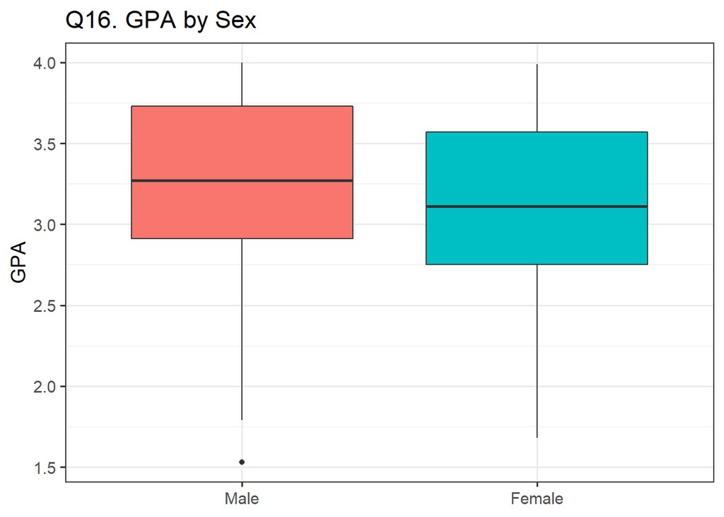

```r
casData <- casData %>%
  mutate(Sex = factor(male, labels = c('Male','Female')))
ggplot(casData, aes(x = Sex, y = GPA, fill = Sex)) +
  geom_boxplot() +
  theme_bw(base_size = 14) +
  theme(legend.position = 'none',
        axis.title.x = element_blank()) +
  labs(title = 'Q16. GPA by Sex')
```

Q17. A table showing the number and proportions of students of each sex who drink/don’t drink

```r
sxdrnk_df <- casData %>%
  group_by(Sex, DRINK) %>%
  summarise(n = n(), .groups = 'drop_last') %>%
  mutate(prop = paste0(round(n/sum(n)*100,1),"%")) %>%
  select(-n) %>%
  spread(DRINK, prop)
colnames(sxdrnk_df)[1] <- 'Sex'
knitr::kable(sxdrnk_df, 'html', align = 'c', caption = 'Q17. Proportions of Drinkers by Sex',  table.attr = "style='width:30%;'")
```

Q17. Proportions of Drinkers by Sex

| Sex | Non-drinker | Drinker |
| --- | --- | --- |
| Male | 34.1% | 65.9% |
| Female | 30.6% | 69.4% |

```r
model4 <- lm(GPA ~ DRINK + male, data=casData)
#summary(model4)
co4 <- coef(model4)
conf4 <- confint(model4)
```

```r
cat('Q18. The estimated mean difference in GPA for students who drink, compared to students of the same sex who do not:\n  ', round(co4[2], 2), '\n')
```

```
## Q18. The estimated mean difference in GPA for students who drink, compared to students of the same sex who do not:
##    -0.18
```

```r
cat('Q19. A 95% confidence interval for this estimated difference:\n  ',
    paste0('(', round(conf4[2,1], 2), ', ', round(conf4[2,2], 2), ')\n'))
```

```
## Q19. A 95% confidence interval for this estimated difference:
##    (-0.28, -0.07)
```

```r
cat('Q20. The estimated mean difference in GPA for male students, compared to female students _of the same drinking status_:\n  ', round(co4[3],2), '\n')
```

```
## Q20. The estimated mean difference in GPA for male students, compared to female students _of the same drinking status_:
##    -0.16
```

```r
cat('Q15. A 95% confidence interval for this estimated difference:\n  ',
    paste0('(', round(conf4[3,1], 2), ', ', round(conf4[3,2], 2), ')'))
```

```
## Q15. A 95% confidence interval for this estimated difference:
##    (-0.26, -0.06)
```